[figure not shown]

# Solution to Shopify Fall 2022 Data Science Intern Challenge

## Victor Francis

### May 16, 2022

## Exploratory Data Analysis

### Imports

```python
import pandas as pd
import numpy as np
import seaborn as sns
import altair as alt
```

```python
df = pd.read_csv("/Users/victorfrancis/Victor/Professional_Applications/2021_and_After/Shopify-Internship/2019 Winter Data Science Intern Challenge Data Set.csv")

df.head()
```

|  | order_id | shop_id | user_id | order_amount | total_items | payment_method | created_at |
| --- | --- | --- | --- | --- | --- | --- | --- |
| 0 | 16 | 42 | 607 | 704000 | 2000 | credit_card | 2017-03-07 4:00:00 |
| 1 | 61 | 42 | 607 | 704000 | 2000 | credit_card | 2017-03-04 4:00:00 |
| 2 | 521 | 42 | 607 | 704000 | 2000 | credit_card | 2017-03-02 4:00:00 |
| 3 | 1105 | 42 | 607 | 704000 | 2000 | credit_card | 2017-03-24 4:00:00 |
| 4 | 1363 | 42 | 607 | 704000 | 2000 | credit_card | 2017-03-15 4:00:00 |

```python
df.describe()
```

|  | order_id | shop_id | user_id | order_amount | total_items |
| --- | --- | --- | --- | --- | --- |
| count | 5000.000000 | 5000.000000 | 5000.000000 | 5000.000000 | 5000.00000 |
| mean | 2500.500000 | 50.078800 | 849.092400 | 3145.128000 | 8.78720 |
| std | 1443.520003 | 29.006118 | 87.798982 | 41282.539349 | 116.32032 |
| min | 1.000000 | 1.000000 | 607.000000 | 90.000000 | 1.00000 |
| 25% | 1250.750000 | 24.000000 | 775.000000 | 163.000000 | 1.00000 |
| 50% | 2500.500000 | 50.000000 | 849.000000 | 284.000000 | 2.00000 |
| 75% | 3750.250000 | 75.000000 | 925.000000 | 390.000000 | 3.00000 |
| max | 5000.000000 | 100.000000 | 999.000000 | 704000.000000 | 2000.00000 |

```python
df.order_amount.describe()
```

```
count      5000.000000
mean       3145.128000
std       41282.539349
min          90.000000
25%         163.000000
50%         284.000000
75%         390.000000
max      704000.000000
Name: order_amount, dtype: float64
```

```python
df.order_amount.mean()
```

```
3145.128
```

```python
df.order_amount.median()
```

```
284.0
```

As we can seen above, there is a large disparity between the mean and the median. Therefore, it is clear that the reported mean is inflated.

```python
df["unit_price"] = df["order_amount"]/df["total_items"]
df.head()
```

|  | order_id | shop_id | user_id | order_amount | total_items | payment_method | created_at | unit_price |
| --- | --- | --- | --- | --- | --- | --- | --- | --- |
| 0 | 16 | 42 | 607 | 704000 | 2000 | credit_card | 2017-03-07 4:00:00 | 352.0 |
| 1 | 61 | 42 | 607 | 704000 | 2000 | credit_card | 2017-03-04 4:00:00 | 352.0 |
| 2 | 521 | 42 | 607 | 704000 | 2000 | credit_card | 2017-03-02 4:00:00 | 352.0 |
| 3 | 1105 | 42 | 607 | 704000 | 2000 | credit_card | 2017-03-24 4:00:00 | 352.0 |
| 4 | 1363 | 42 | 607 | 704000 | 2000 | credit_card | 2017-03-15 4:00:00 | 352.0 |

The unit price is now rightly computed

```python
count_of_order_volume = (df.groupby(['total_items'])['order_id'].nunique()
                       .to_frame()
                       .reset_index()
                       .rename(columns={'order_id':'count'}))
```

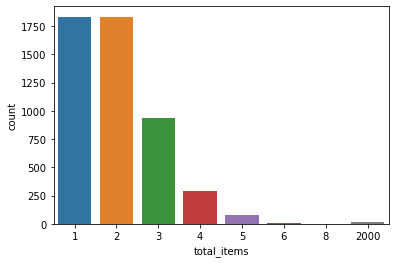

```python
sns.barplot(data=count_of_order_volume,
            x='total_items',
            y='count')
```

```python
df_count = df.groupby("total_items").count().reset_index()
df_count
```

|  | total_items | order_id | shop_id | user_id | order_amount | payment_method | created_at | unit_price |
| --- | --- | --- | --- | --- | --- | --- | --- | --- |
| 0 | 1 | 1830 | 1830 | 1830 | 1830 | 1830 | 1830 | 1830 |
| 1 | 2 | 1832 | 1832 | 1832 | 1832 | 1832 | 1832 | 1832 |
| 2 | 3 | 941 | 941 | 941 | 941 | 941 | 941 | 941 |
| 3 | 4 | 293 | 293 | 293 | 293 | 293 | 293 | 293 |
| 4 | 5 | 77 | 77 | 77 | 77 | 77 | 77 | 77 |
| 5 | 6 | 9 | 9 | 9 | 9 | 9 | 9 | 9 |
| 6 | 8 | 1 | 1 | 1 | 1 | 1 | 1 | 1 |
| 7 | 2000 | 17 | 17 | 17 | 17 | 17 | 17 | 17 |

```python
alt.Chart(df_count).mark_bar().encode(x="total_items", y="order_id")
```

[interactive chart not shown]

Also, based on the plots above, the outlier is clear as day

```python
df.unit_price.mean()
```

```
387.7428
```

```python
df.unit_price.median()
```

```
153.0
```

### Question 1:

Given some sample data, write a program to answer the following: [click here to access the required data set](https://docs.google.com/spreadsheets/d/16i38oonuX1y1g7C_UAmiK9GkY7cS-64DfiDMNiR41LM/edit#gid=0)

On Shopify, we have exactly 100 sneaker shops, and each of these shops sells only one model of shoe. We want to do some analysis of the average order value (AOV). When we look at orders data over a 30 day window, we naively calculate an AOV of $3145.13. Given that we know these shops are selling sneakers, a relatively affordable item, something seems wrong with our analysis.

`a`: Think about what could be going wrong with our calculation. Think about a better way to evaluate this data.

`b`: What metric would you report for this dataset?

`c`: What is its value?

### Solution to Question 1:

`a`: The computation of `AOV` is wrong because `total_items` (number of items ordered) is greater than 1 in some instance, thereby inflating the AOV. The correct AOV can be computed by firstly dividing the `order_amount` by `total_items` before computing the average. However, AOV is itself is a problematic metric.

`b`: **Median Order Value (MOV)**. This is because of the possibility of skewness/outliers. It is well known that mean is a very bad metric for an outlier-prone/skewed dataset. Therefore, `Median Order Value` will be my metric of choice.

```python
df.unit_price.median()
```

```
153.0
```

### Question 2:

For this question you’ll need to use SQL. [Follow this link](https://www.w3schools.com/SQL/TRYSQL.ASP?FILENAME=TRYSQL_SELECT_ALL) to access the data set required for the challenge. Please use queries to answer the following questions. Paste your queries along with your final numerical answers below.

`a`: How many orders were shipped by Speedy Express in total?

`b`: What is the last name of the employee with the most orders?

`c`: What product was ordered the most by customers in Germany?

### Solution to Question 2

`a`: **54** orders were shipped by Speedy Express

```
SELECT
    COUNT(*)
FROM
    Shippers
JOIN
    Orders
    ON Shippers.ShipperID = Orders.ShipperID
WHERE
    ShipperName = 'Speedy Express'
;
```

`b`: **Peacock** is the last name of the employee with the most orders

```
SELECT
    LastName
FROM
    [Employees]
JOIN
    Orders
    ON Employees.EmployeeID = Orders.EmployeeID
GROUP BY
    Employees.EmployeeID
ORDER BY
    COUNT(*) DESC
LIMIT 1
;
```

`c`: **Boston Crab Meat** was ordered the most by customers in Germany

```
SELECT
    ProductName
FROM
    Customers
JOIN
    Orders
    ON Orders.CustomerID = Customers.CustomerID
    JOIN OrderDetails ON Orders.OrderID = OrderDetails.OrderID
    JOIN Products ON Products.ProductID = OrderDetails.ProductID
WHERE
    Country='Germany'
GROUP BY
    Products.ProductID
ORDER BY
    SUM(Quantity) DESC
LIMIT 1
;
```

[figure not shown]

```python
from IPython.display import Image
display(Image(data=open("/Users/victorfrancis/Victor/Professional_Applications/2021_and_After/Shopify-Internship/Shopify_Fall_2022_Data_Science_Intern_Challenge/giphy2.gif",'rb').read(), format='png'))
```